# Applying symbology based on a variable

# The scale_*_* function

When you set the symbology with the `aes()` function, you can customize the legend (and the details of the display), using a corresponding `scale_*_*` function (I’m using stars there to represent a fill-in-the-blank).

For example, since I used the `aes()` function to set the point shape to vary by airport type, I can use `scale_shape()` to customize that legend. I can set the legend title using `name =` and I can set the labels for the individual legend elements using `labels =`.

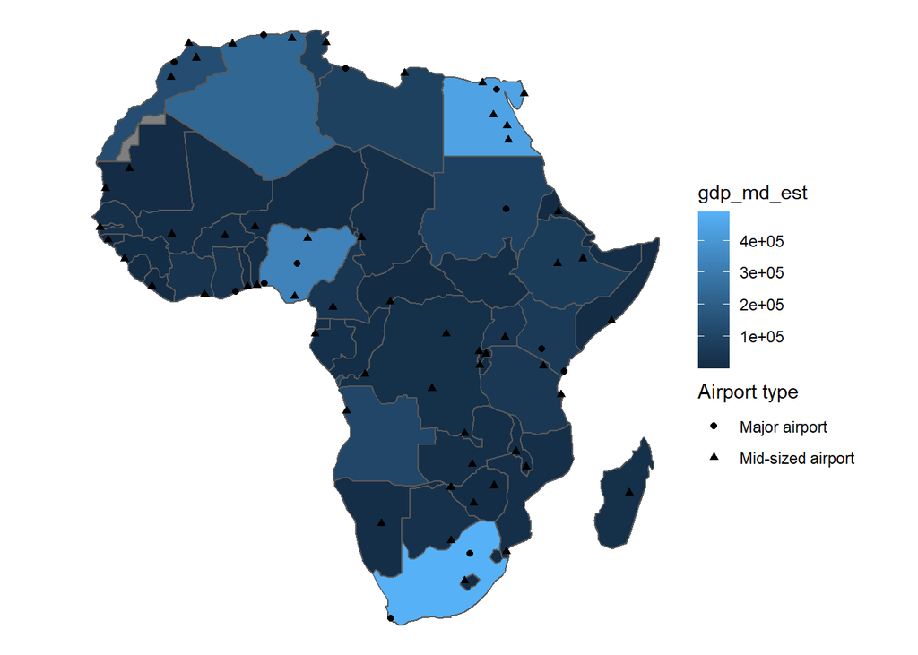

```r
ggplot() +
  geom_sf(data = countries,
          aes(fill = gdp_md_est)) +
  geom_sf(data = airports,
          aes(shape = type)) +
  scale_shape(name = "Airport type",
              labels = c("Major airport",
                         "Mid-sized airport")) +
  theme_void()
```

Alternatively, I can use `scale_shape_manual` if I also want to change the specific shapes that are on the legend *and* on the map. `16` refers to a solid dot and `1` refers to an open dot ([for more on point symbology options, see this page](https://c-voulgaris.github.io/VIS-2128-F22/a2-files/skill-layer-symbology.html)).

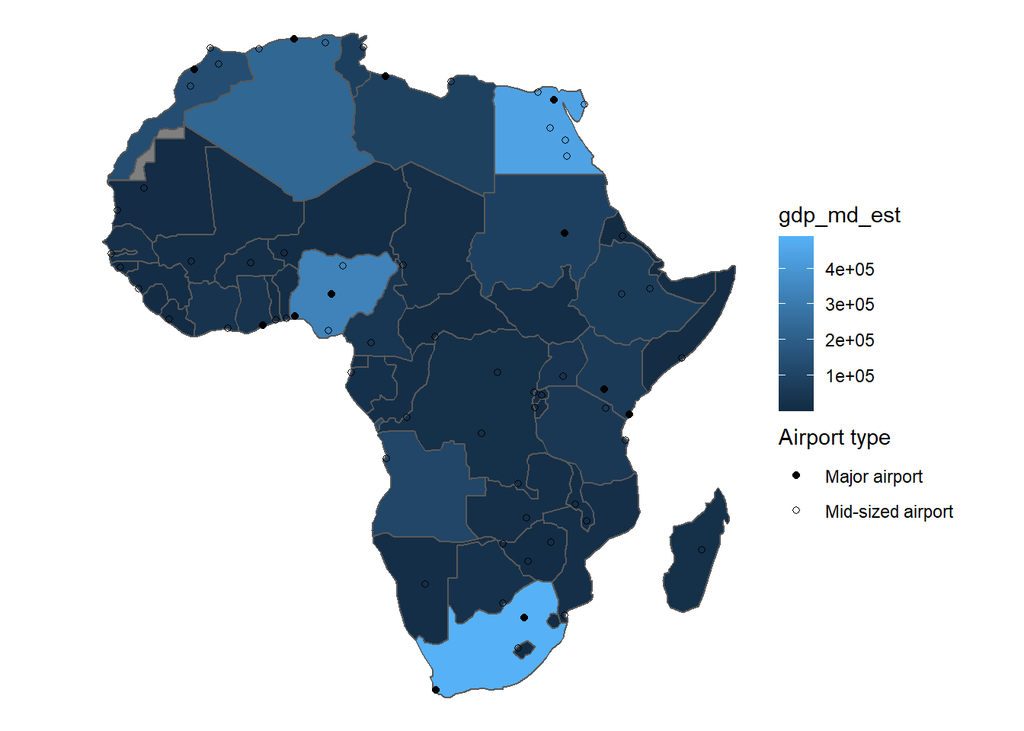

```r
ggplot() +
  geom_sf(data = countries,
          aes(fill = gdp_md_est)) +
  geom_sf(data = airports,
          aes(shape = type)) +
  scale_shape_manual(name = "Airport type",
              labels = c("Major airport",
                         "Mid-sized airport"),
              values = c(16, 1)) +
  theme_void()
```

Likewise, I can use `scale_fill_continuous()` to set the title and labels for the color legend. Since this is a continuous variable, I’ll need to specify which values on the color ramp will be labeled using `breaks =` in addition to how they will be labeled.

```r
ggplot() +
  geom_sf(data = countries,
          aes(fill = gdp_md_est)) +
  geom_sf(data = airports,
          aes(shape = type)) +
  scale_shape_manual(name = "Airport type",
              labels = c("Major airport",
                         "Mid-sized airport"),
              values = c(16, 1)) +
  scale_fill_continuous(name = "Estimated GDP",
                        breaks = c(100000,
                                   200000,
                                   300000,
                                   400000),
              labels = c("$100 Billion",
                         "$200 Billion",
                         "$300 Billion",
                         "$400 Billion")) +
  theme_void()
```

[output not shown]

There are some shortcuts to defining breaks and labels. The `seq()` function will create a set of sequential numbers for you, so save you having to type them all out. Here is how I would specify that I want breaks from 100,000 to 400,000, increasing in units of 100,000.

```r
ggplot() +
  geom_sf(data = countries,
          aes(fill = gdp_md_est)) +
  geom_sf(data = airports,
          aes(shape = type)) +
  scale_shape_manual(name = "Airport type",
              labels = c("Major airport",
                         "Mid-sized airport"),
              values = c(16, 1)) +
  scale_fill_continuous(name = "Estimated GDP",
                        breaks = seq(100000, 400000,
                                     by=100000),
              labels = c("$100 Billion",
                         "$200 Billion",
                         "$300 Billion",
                         "$400 Billion")) +
  theme_void()
```

[output not shown]

If I set the break values as breaks = my_breaks <- seq(…), that will temporarily store those break values and I can use them to set up my labels.

The `paste0()` function is handy for setting up labels. In the example below, I’m specifying that the labels should start with a “$”, followed by the break value divided by 1000 (since the variable reports the value in millions), followed by a space and the word “Billion.”

```r
ggplot() +
  geom_sf(data = countries,
          aes(fill = gdp_md_est)) +
  geom_sf(data = airports,
          aes(shape = type)) +
  scale_shape_manual(name = "Airport type",
              labels = c("Major airport",
                         "Mid-sized airport"),
              values = c(16, 1)) +
  scale_fill_continuous(name = "Estimated GDP",
                        breaks = my_breaks <- seq(100000, 400000,
                                                  by=100000),
              labels = paste0("$", my_breaks / 1000, " Billion")) +
  theme_void()
```

[output not shown]

You can also customize the color ramp using variations on `scale_fill_gradient()` or `scale_fill_viridis_c()`. More on that in the [fun with color palettes skill](https://c-voulgaris.github.io/VIS-2128-F22/a2-files/skill-colors.html).

To further customize the appearance of the legend, refer to [customizing ggplot themes](https://c-voulgaris.github.io/VIS-2128-F22/a2-files/skill-custom-themes.html).